# MODULE 4 PROJECT

### Travel Package Purchase Prediction - Problem Statement

#### Background and Context

You are a Data Scientist for a tourism company named "Visit with us". The Policy Maker of the company wants to enable and establish a viable business model to expand the customer base.

A viable business model is a central concept that helps you to understand the existing ways of doing the business and how to change the ways for the benefit of the tourism sector.

One of the ways to expand the customer base is to introduce a new offering of packages.

Currently, there are 5 types of packages the company is offering - Basic, Standard, Deluxe, Super Deluxe, King. Looking at the data of the last year, we observed that 18% of the customers purchased the packages.

However, the marketing cost was quite high because customers were contacted at random without looking at the available information.

The company is now planning to launch a new product i.e. Wellness Tourism Package. Wellness Tourism is defined as Travel that allows the traveler to maintain, enhance or kick-start a healthy lifestyle, and support or increase one's sense of well-being.

However, this time company wants to harness the available data of existing and potential customers to make the marketing expenditure more efficient.

You as a Data Scientist at "Visit with us" travel company have to analyze the customers' data and information to provide recommendations to the Policy Maker and Marketing Team and also build a model to predict the potential customer who is going to purchase the newly introduced travel package.

#### Objective

To predict which customer is more likely to purchase the newly introduced travel package.

#### Customer details:

- CustomerID: Unique customer ID
- ProdTaken: Whether the customer has purchased a package or not (0: No, 1: Yes)
- Age: Age of customer
- TypeofContact: How customer was contacted (Company Invited or Self Inquiry)
- CityTier: City tier depends on the development of a city, population, facilities, and living standards. The categories are ordered i.e. Tier 1 > Tier 2 > Tier 3
- Occupation: Occupation of customer
- Gender: Gender of customer
- NumberOfPersonVisiting: Total number of persons planning to take the trip with the customer
- PreferredPropertyStar: Preferred hotel property rating by customer
- MaritalStatus: Marital status of customer
- NumberOfTrips: Average number of trips in a year by customer
- Passport: The customer has a passport or not (0: No, 1: Yes)
- OwnCar: Whether the customers own a car or not (0: No, 1: Yes)
- NumberOfChildrenVisiting: Total number of children with age less than 5 planning to take the trip with the customer
- Designation: Designation of the customer in the current organization
- MonthlyIncome: Gross monthly income of the customer

#### Customer interaction data:

- PitchSatisfactionScore: Sales pitch satisfaction score
- ProductPitched: Product pitched by the salesperson
- NumberOfFollowups: Total number of follow-ups has been done by the salesperson after the sales pitch
- DurationOfPitch: Duration of the pitch by a salesperson to the customer

```python
# Let's import relevant libraries

# Libraries to help with reading and manipulating data
import pandas as pd
import numpy as np

# Libraries to help with reading and manipulating data
import matplotlib.pyplot as plt
import seaborn as sns
%matplotlib inline
sns.set(color_codes=True)

 # to split the data into train and test and GridSearchCV for parameter tuning
from sklearn.model_selection import train_test_split, GridSearchCV



from sklearn.tree import DecisionTreeClassifier # to build decision tree

#To build models with various ensemble methods
from sklearn.ensemble import BaggingClassifier, RandomForestClassifier, AdaBoostClassifier, GradientBoostingClassifier,StackingClassifier
from xgboost import XGBClassifier

 # to check model performance and build confusion matrix
from sklearn import metrics
from sklearn.metrics import accuracy_score,recall_score, precision_score,f1_score,confusion_matrix
#from mlxtend.classifier import StackingClassifier

# To filter warnings
import warnings
warnings.filterwarnings('ignore')
```

```python
# Let's upload the dataset to work with
data=pd.read_excel('Tourism.xlsx')
data.head()# to check the first 5 rows of the dataset
```

|  | CustomerID | ProdTaken | Age | TypeofContact | CityTier | DurationOfPitch | Occupation | Gender | NumberOfPersonVisiting | NumberOfFollowups | ProductPitched | PreferredPropertyStar | MaritalStatus | NumberOfTrips | Passport | PitchSatisfactionScore | OwnCar | NumberOfChildrenVisiting | Designation | MonthlyIncome |
| --- | --- | --- | --- | --- | --- | --- | --- | --- | --- | --- | --- | --- | --- | --- | --- | --- | --- | --- | --- | --- |
| 0 | 200000 | 1 | 41.0 | Self Enquiry | 3 | 6.0 | Salaried | Female | 3 | 3.0 | Deluxe | 3.0 | Single | 1.0 | 1 | 2 | 1 | 0.0 | Manager | 20993.0 |
| 1 | 200001 | 0 | 49.0 | Company Invited | 1 | 14.0 | Salaried | Male | 3 | 4.0 | Deluxe | 4.0 | Divorced | 2.0 | 0 | 3 | 1 | 2.0 | Manager | 20130.0 |
| 2 | 200002 | 1 | 37.0 | Self Enquiry | 1 | 8.0 | Free Lancer | Male | 3 | 4.0 | Basic | 3.0 | Single | 7.0 | 1 | 3 | 0 | 0.0 | Executive | 17090.0 |
| 3 | 200003 | 0 | 33.0 | Company Invited | 1 | 9.0 | Salaried | Female | 2 | 3.0 | Basic | 3.0 | Divorced | 2.0 | 1 | 5 | 1 | 1.0 | Executive | 17909.0 |
| 4 | 200004 | 0 | NaN | Self Enquiry | 1 | 8.0 | Small Business | Male | 2 | 3.0 | Basic | 4.0 | Divorced | 1.0 | 0 | 5 | 1 | 0.0 | Executive | 18468.0 |

- The dataset looks consistent with the description provided in the Data Dictionary. However, the CustomerID column does not contain any information relevant to the project object. This column will be dropped shortly in the project.

```python
df=data.copy()#To save a copy of the original data
```

```python
df.shape #To check the number of rows and columns in the data
```

```
(4888, 20)
```

- The dataset has 4888 rows and 20 columns

```python
df.duplicated().sum() # To check if there is any duplicated row in the dataset
```

```
0
```

- There is no duplicated row in the dataset

```python
df.info() #To print the concise summary of the dataset
```

```
<class 'pandas.core.frame.DataFrame'>
RangeIndex: 4888 entries, 0 to 4887
Data columns (total 20 columns):
 #   Column                    Non-Null Count  Dtype
---  ------                    --------------  -----
 0   CustomerID                4888 non-null   int64
 1   ProdTaken                 4888 non-null   int64
 2   Age                       4662 non-null   float64
 3   TypeofContact             4863 non-null   object
 4   CityTier                  4888 non-null   int64
 5   DurationOfPitch           4637 non-null   float64
 6   Occupation                4888 non-null   object
 7   Gender                    4888 non-null   object
 8   NumberOfPersonVisiting    4888 non-null   int64
 9   NumberOfFollowups         4843 non-null   float64
 10  ProductPitched            4888 non-null   object
 11  PreferredPropertyStar     4862 non-null   float64
 12  MaritalStatus             4888 non-null   object
 13  NumberOfTrips             4748 non-null   float64
 14  Passport                  4888 non-null   int64
 15  PitchSatisfactionScore    4888 non-null   int64
 16  OwnCar                    4888 non-null   int64
 17  NumberOfChildrenVisiting  4822 non-null   float64
 18  Designation               4888 non-null   object
 19  MonthlyIncome             4655 non-null   float64
dtypes: float64(7), int64(7), object(6)
memory usage: 763.9+ KB
```

```python
df.isnull().sum() #To further confirm if there are missing values in the data set or not
```

```
CustomerID                    0
ProdTaken                     0
Age                         226
TypeofContact                25
CityTier                      0
DurationOfPitch             251
Occupation                    0
Gender                        0
NumberOfPersonVisiting        0
NumberOfFollowups            45
ProductPitched                0
PreferredPropertyStar        26
MaritalStatus                 0
NumberOfTrips               140
Passport                      0
PitchSatisfactionScore        0
OwnCar                        0
NumberOfChildrenVisiting     66
Designation                   0
MonthlyIncome               233
dtype: int64
```

- As observed earlier, there are missing values in Age, TypeofContact, DurationOfPitch, NumberOfFollowups, PreferredPropertyStar, NumberOfTrips, NumberofChildrenVisiting and MonthlyIncome. THis will be worked upon later in the project

```python
df.drop('CustomerID',axis=1,inplace=True) #To drop the CustomerID column as it contains no relevant information to the project objective
```

```python
cols =df.select_dtypes(['object'])#to display the categorical features
cols.columns
```

```
Index(['TypeofContact', 'Occupation', 'Gender', 'ProductPitched',
       'MaritalStatus', 'Designation'],
      dtype='object')
```

```python
for i in cols.columns:
    df[i]=df[i].astype('category') #to convert them to category data type
```

```python
df.columns #To check the names of the features on the dataset properly
```

```
Index(['ProdTaken', 'Age', 'TypeofContact', 'CityTier', 'DurationOfPitch',
       'Occupation', 'Gender', 'NumberOfPersonVisiting', 'NumberOfFollowups',
       'ProductPitched', 'PreferredPropertyStar', 'MaritalStatus',
       'NumberOfTrips', 'Passport', 'PitchSatisfactionScore', 'OwnCar',
       'NumberOfChildrenVisiting', 'Designation', 'MonthlyIncome'],
      dtype='object')
```

- From the project object, it is clear that the target feature of ProdTaken while the rest are independent variables/predictors

### Summary of the dataset

```python
df.describe().T #to display the statistical summary of the numerical data
```

|  | count | mean | std | min | 25% | 50% | 75% | max |
| --- | --- | --- | --- | --- | --- | --- | --- | --- |
| ProdTaken | 4888.0 | 0.188216 | 0.390925 | 0.0 | 0.0 | 0.0 | 0.0 | 1.0 |
| Age | 4662.0 | 37.622265 | 9.316387 | 18.0 | 31.0 | 36.0 | 44.0 | 61.0 |
| CityTier | 4888.0 | 1.654255 | 0.916583 | 1.0 | 1.0 | 1.0 | 3.0 | 3.0 |
| DurationOfPitch | 4637.0 | 15.490835 | 8.519643 | 5.0 | 9.0 | 13.0 | 20.0 | 127.0 |
| NumberOfPersonVisiting | 4888.0 | 2.905074 | 0.724891 | 1.0 | 2.0 | 3.0 | 3.0 | 5.0 |
| NumberOfFollowups | 4843.0 | 3.708445 | 1.002509 | 1.0 | 3.0 | 4.0 | 4.0 | 6.0 |
| PreferredPropertyStar | 4862.0 | 3.581037 | 0.798009 | 3.0 | 3.0 | 3.0 | 4.0 | 5.0 |
| NumberOfTrips | 4748.0 | 3.236521 | 1.849019 | 1.0 | 2.0 | 3.0 | 4.0 | 22.0 |
| Passport | 4888.0 | 0.290917 | 0.454232 | 0.0 | 0.0 | 0.0 | 1.0 | 1.0 |
| PitchSatisfactionScore | 4888.0 | 3.078151 | 1.365792 | 1.0 | 2.0 | 3.0 | 4.0 | 5.0 |
| OwnCar | 4888.0 | 0.620295 | 0.485363 | 0.0 | 0.0 | 1.0 | 1.0 | 1.0 |
| NumberOfChildrenVisiting | 4822.0 | 1.187267 | 0.857861 | 0.0 | 1.0 | 1.0 | 2.0 | 3.0 |
| MonthlyIncome | 4655.0 | 23619.853491 | 5380.698361 | 1000.0 | 20346.0 | 22347.0 | 25571.0 | 98678.0 |

- The mean, Standard deviation and Median(50th Percentile) of all numerical features are all displayed above. However worthy of mention is that the Mean Age of the customers is 37.6 while the oldest customer is 61. The DurationOfPitch also has mean,median and maximum number as 15.49,13.0, and 127 respectively. This suggests a right-skewed distribution. This same pattern can be observed in the NumberOfTrips. We shall explore these distributions further shortly.

```python
df.describe(include=['category']).T #to display the statistical summary of the categorical data
```

|  | count | unique | top | freq |
| --- | --- | --- | --- | --- |
| TypeofContact | 4863 | 2 | Self Enquiry | 3444 |
| Occupation | 4888 | 4 | Salaried | 2368 |
| Gender | 4888 | 3 | Male | 2916 |
| ProductPitched | 4888 | 5 | Basic | 1842 |
| MaritalStatus | 4888 | 4 | Married | 2340 |
| Designation | 4888 | 5 | Executive | 1842 |

- The number of unique values in the each of the categorical feature and the unique value with the highest frequency are displayed above.

### Let's look at the unique values of all the categorical features

```python
#To display the unique values in each categorical features
col_cat= df.select_dtypes(['category'])
for i in col_cat.columns:
    print('Unique values in', i, 'are:')
    print(col_cat[i].value_counts())
    print('*'*50)
```

```
Unique values in TypeofContact are:
Self Enquiry       3444
Company Invited    1419
Name: TypeofContact, dtype: int64
Unique values in Occupation are:
Salaried          2368
Small Business    2084
Large Business     434
Free Lancer          2
Name: Occupation, dtype: int64
Unique values in Gender are:
Male       2916
Female     1817
Fe Male     155
Name: Gender, dtype: int64
Unique values in ProductPitched are:
Basic           1842
Deluxe          1732
Standard         742
Super Deluxe     342
King             230
Name: ProductPitched, dtype: int64
Unique values in MaritalStatus are:
Married      2340
Divorced      950
Single        916
Unmarried     682
Name: MaritalStatus, dtype: int64
Unique values in Designation are:
Executive         1842
Manager           1732
Senior Manager     742
AVP                342
VP                 230
Name: Designation, dtype: int64
```

- It is observed that there is a typo error in the unique values of Gender as we can see 'Female' and 'Fe Male' returned as two different genders. This needs to be corrected

```python
df['Gender']=df['Gender'].replace('Fe Male','Female') # to correct the typo error in Gender by changing all 'Fe Male' to Female
```

```python
df['Gender'].value_counts()#To reconfirm the unique values in Gender
```

```
Male      2916
Female    1972
Name: Gender, dtype: int64
```

- The typo error has been corrected now

## Univariate Analysis

```python
# Function to create both boxplot and histogram that will contain both mean and median values of applicable variables.
def hist_boxplt(feature, figsize=(15, 10), bins=None):
    sns.set(font_scale=2)
    f2, (ax_box2, ax_hist2) = plt.subplots(
        nrows=2,
        sharex=True,
        gridspec_kw={"height_ratios": (0.25, 0.75)},
        figsize=figsize,
    )
    sns.boxplot(feature, ax=ax_box2, showmeans=True, color="red")
    sns.distplot(feature, kde=True, ax=ax_hist2, bins=bins) if bins else sns.distplot(
        feature, kde=True, ax=ax_hist2
    )
    ax_hist2.axvline(np.mean(feature), color="g", linestyle="--")
    ax_hist2.axvline(np.median(feature), color="black", linestyle="-")




# Function to create barplots that indicate percentage for each category.
def perc_on_bar(feature):
    total = len(feature)  # length of the column
    plt.figure(figsize=(15, 5))
    ax = sns.countplot(feature, palette="bright")
    for p in ax.patches:
        percentage = "{:.1f}%".format(
            100 * p.get_height() / total
        )  # to show percentage of each class of the category
        x = p.get_x() + p.get_width() / 2 - 0.05  # defining width of the plot
        y = p.get_y() + p.get_height()  # defining the height of the plot

        ax.annotate(percentage, (x, y), size=15)  # to annotate the percantage
    plt.show()  # to show the plot
```

### ProdTaken

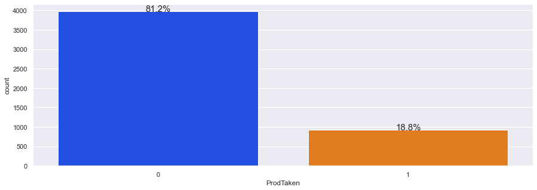

```python
perc_on_bar(df.ProdTaken)# to create barplot of ProdTaken
```

- It can be confirmed now that 81.2% of the customers did not purchase any product the last time while only 18.8% purchased the product

### Age

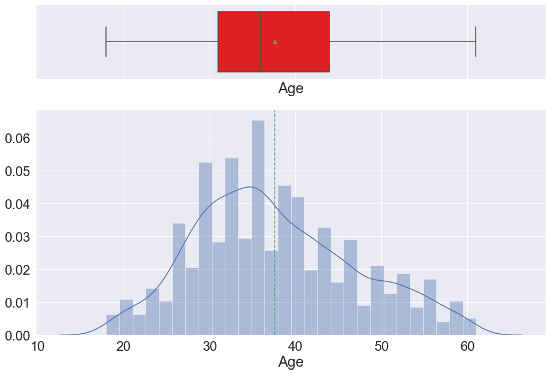

```python
hist_boxplt(df.Age) # To plot the boxplot and histogram of Age
```

- It can be observed that the customer'age distribution is close to normal distribution but 75% of the customers are less than 45years in age. There is also no outlier in the distribution

### TypeofContact

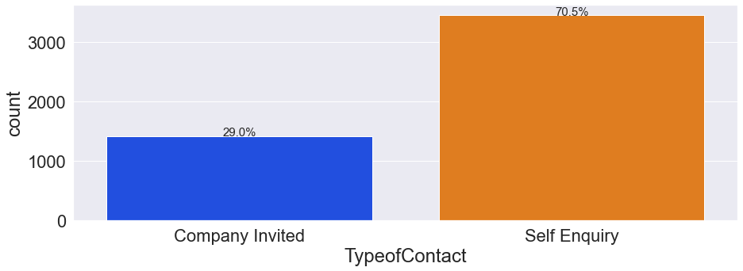

```python
perc_on_bar(df.TypeofContact)# to create barplot of TypeofContact
```

- Most of the company customers contacted the company by themselves while only 29% of the customers are company invited. This means that the company self enquiry channels are bring in more prospective customers than the company invitation system

### CityTier

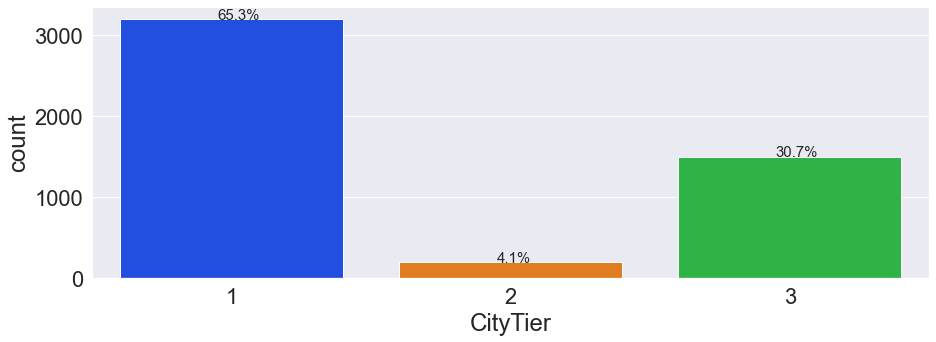

```python
perc_on_bar(df.CityTier)# to create barplot of CityTier
```

- Majority(65.3% representing over 3000) of the company customers are from Tier 1 cities(highly developed and populous cities) while Tier 2 cities are the least contributors to the customer base of the company

### Occupation

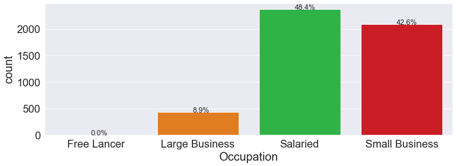

```python
perc_on_bar(df.Occupation)# to create barplot of Occupation
```

- Highest percentage(48.4%) of the company customers are Salary earners closely followed by small business owners(42.6%). Free Lancers are the least in number among the company customers

### Gender

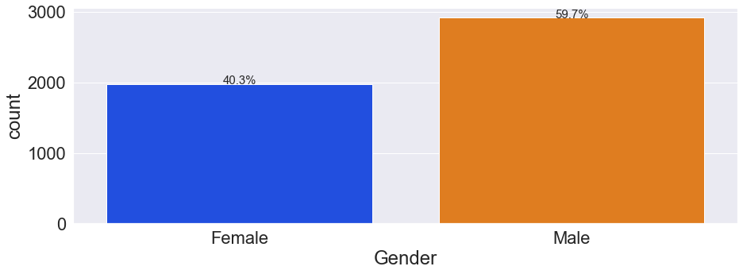

```python
perc_on_bar(df.Gender)# to create barplot of Gender
```

- 59.7% of the company customers are males while 40.3% are females.

### NumberOfPersonVisiting

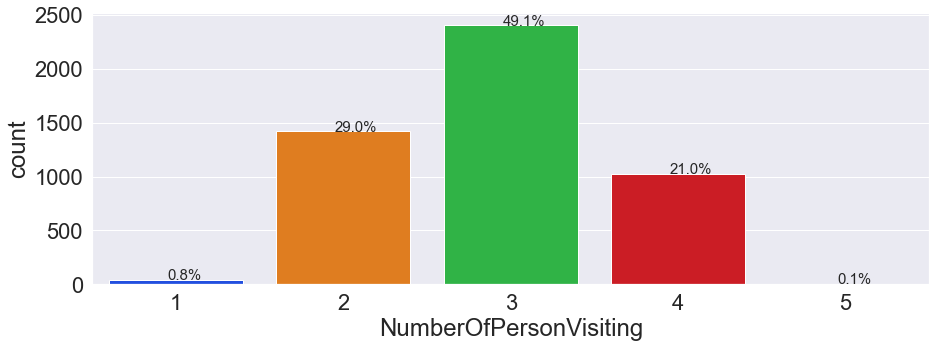

```python
perc_on_bar(df.NumberOfPersonVisiting)# to create barplot of NumberOfPersonVisiting
```

- Highest percentage (49.1%) of the customers travel in threes, followed by those that make trips in twos(29.0%). Those that make trips in fives are the least in number among the company customers accounting for only 0.1%

### PreferredPropertyStar

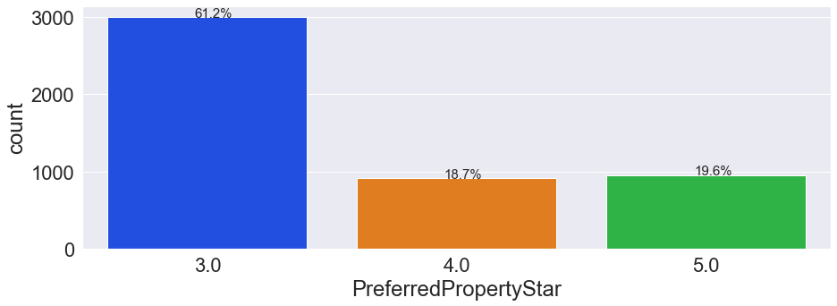

```python
perc_on_bar(df.PreferredPropertyStar)# to create barplot of PreferredPropertyStar
```

- Preferred hotel property rating 3.0 is the rating 61.2% of the customers gave while 18.7% customers gave 4.0 rating.

### MaritalStatus

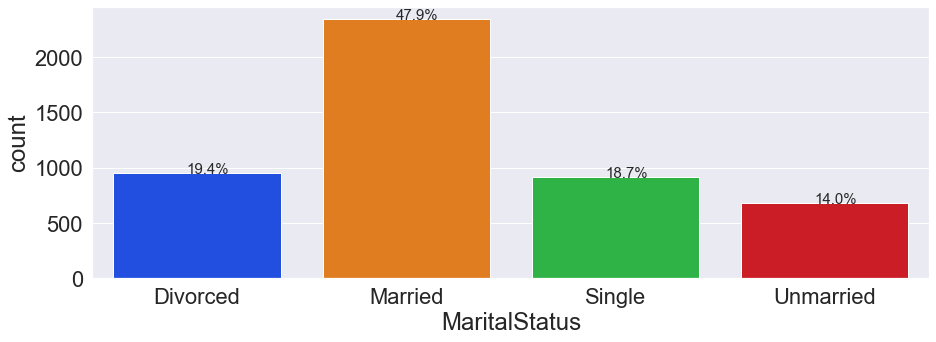

```python
perc_on_bar(df.MaritalStatus)# to create barplot of MaritalStatus
```

- Over 2000 of the company customers are married constituting the majority number(47.9%) while the unmarried are the least number among the company's customers

### NumberOfTrips

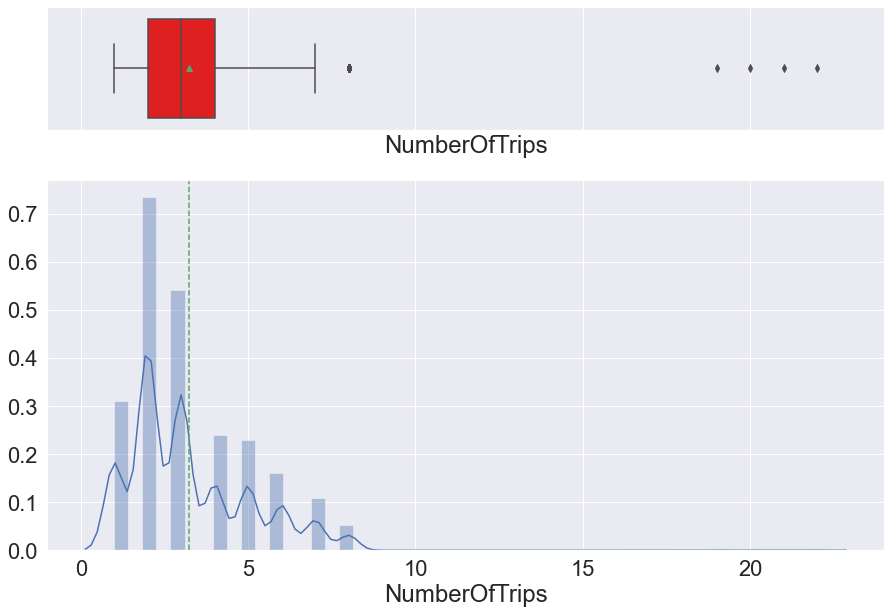

```python
hist_boxplt(df.NumberOfTrips) # To plot the boxplot and histogram of NumberOfTrips
```

- It can be observed that the highest number of customers made only 2 trips last year, followed by those that made 3 trips. 75% of the customers made 4 trips and below last year. The NumberOfTrips distribution is right-skewed with some outliers as shown in the boxplot. This distribution can also be visualise in barplots as shown below

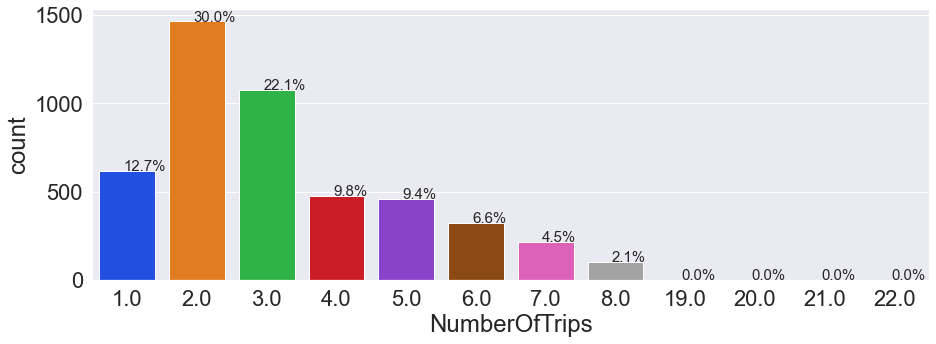

```python
perc_on_bar(df.NumberOfTrips)# to create barplot of NumberOfTrips
```

### Passport

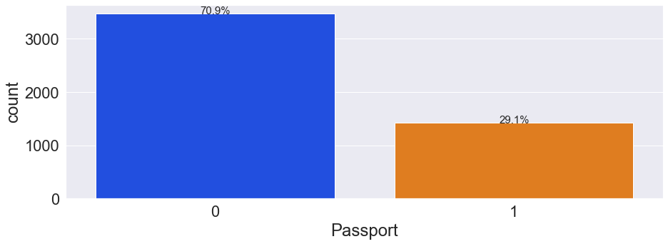

```python
perc_on_bar(df.Passport) #To create barplot of Passport
```

- 70.9% of the company customers do not have a passport while only 29.1% do. This means that the company will need to position tourism packages which require no passport to thier customers so that they can serve these customers without passport also

### OwnCar

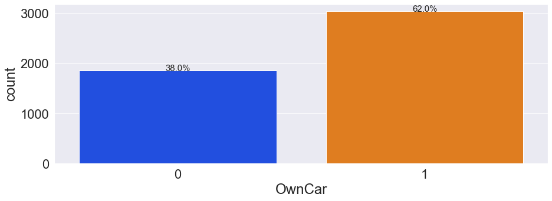

```python
perc_on_bar(df.OwnCar)# to create barplot of OwnCar
```

- 62% representing over 3000 customers are car owners while only 38% do not.

### NumberOfChildrenVisiting

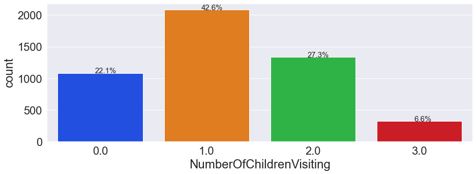

```python
perc_on_bar(df.NumberOfChildrenVisiting)# to create barplot of NumberOfChildrenVisiting
```

- Over 2000 customers have just one child travelling with them while those travelling with 3 children are the least

### Designation

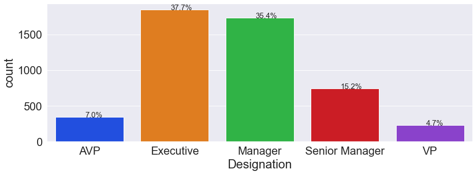

```python
perc_on_bar(df.Designation)# to create barplot of Designation
```

- Customers of Executive and Manager status constitute more than 70% for the company customer base while only customers with VP status are the lowest in number

### MonthlyIncome

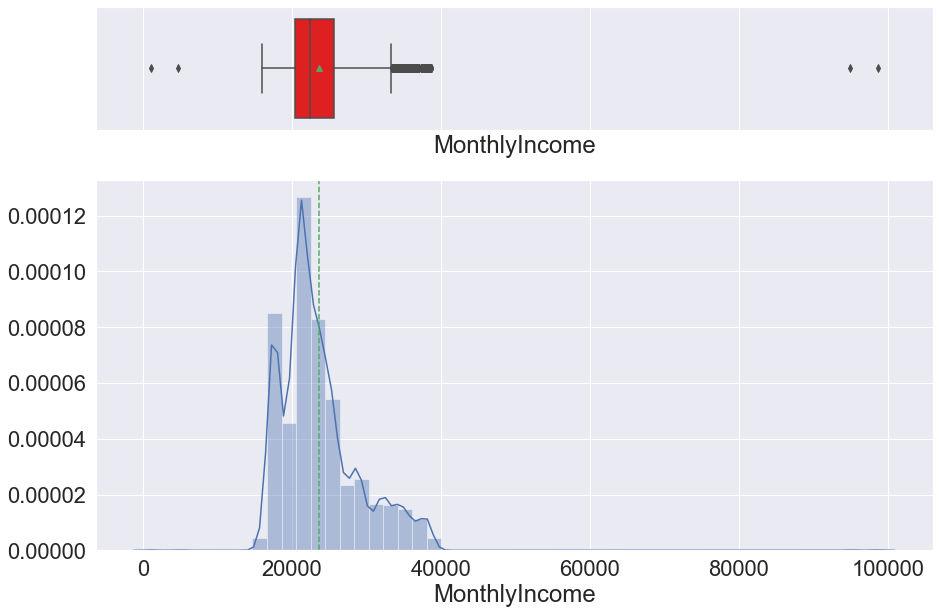

```python
hist_boxplt(df.MonthlyIncome) # To plot the boxplot and histogram of MonthlyIncome
```

- 75% of the customers earn less than 30,000 monthly. The MonthlyIncome distribution of the customer is more skewed to the right but have outliers on both sides

### PitchSatisfactionScore

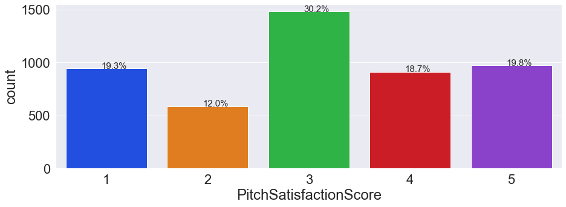

```python
perc_on_bar(df.PitchSatisfactionScore)# to create barplot of PitchSatisfactionScore
```

### ProductPitched

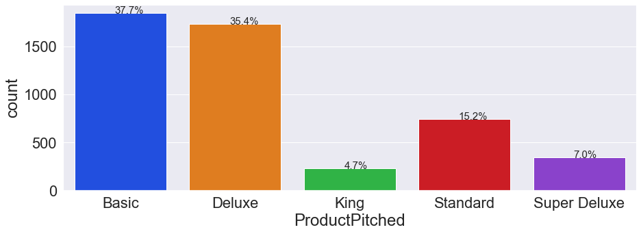

```python
perc_on_bar(df.ProductPitched)# to create barplot of ProductPitched
```

- Products pitched by the salespersons of the company to over 73% of the customers are either Basic or Deluxe while King is the the least pitched product of the company.

### NumberOfFollowups

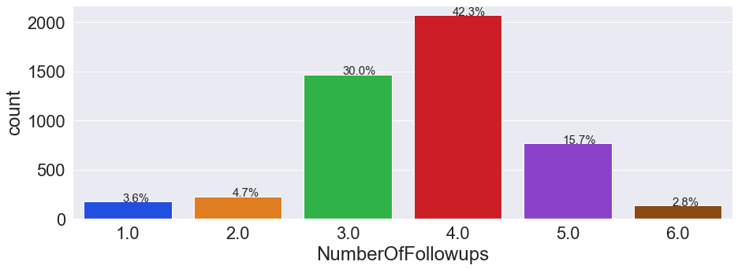

```python
perc_on_bar(df.NumberOfFollowups)# to create barplot of NumberOfFollowups
```

- Over 42% of the customers enjoyed 4 follow-ups from the company salespersons after the sales pitches. Over 72% experienced between 3 and 4 follow-ups from the salespersons while only 2.8% of the customers were given 6 follow-ups

### DurationOfPitch

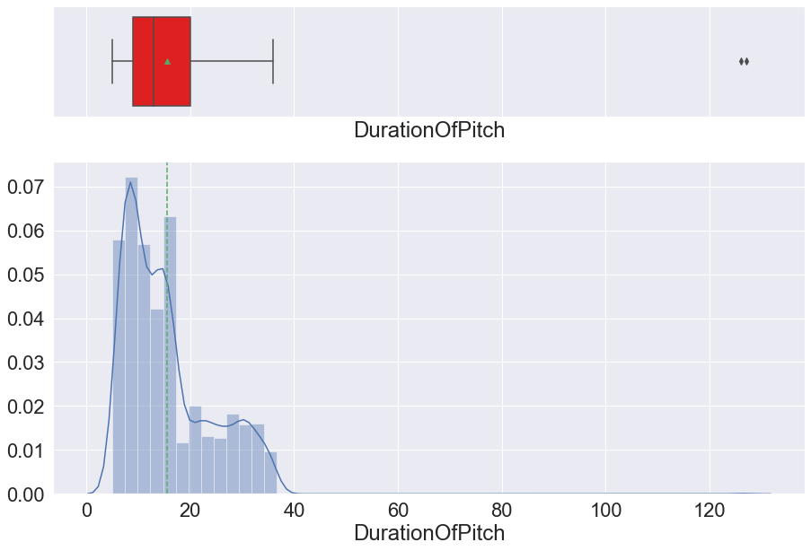

```python
hist_boxplt(df.DurationOfPitch) # To plot the boxplot and histogram of DurationOfPitch
```

- The company salespersons have 20(maybe seconds/minutes) pitch duration with 75% of the customers. From the boxplot and the histogram, it is clear that the DurationOfPitch distribution is right-skewed as discovered earlier with some outliers at the far right

## Bivariate Analysis

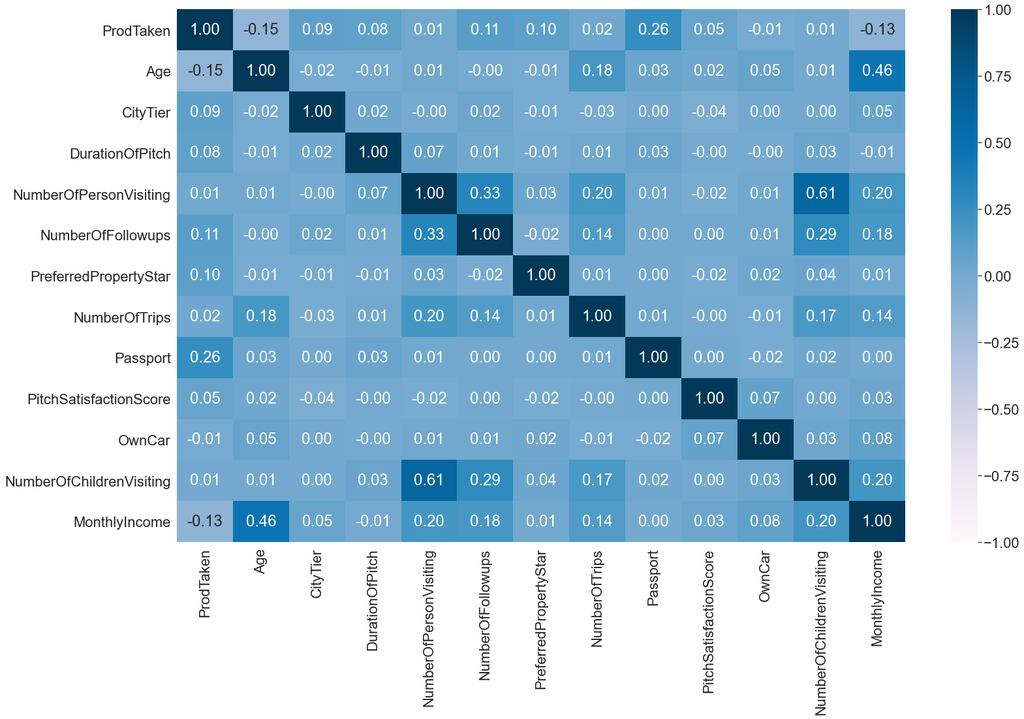

```python
# we shall plot the heatmap of the correlation ratio among the numerical data
plt.figure(figsize=(25, 15))
sns.heatmap(df.corr(), annot=True, vmin=-1, vmax=1, fmt=".2f", cmap="PuBu")
plt.show()
```

- The heatmap above does not show a strong relationship between our target variable(ProdTaken) and any of the independent variables. This will however be investigated further

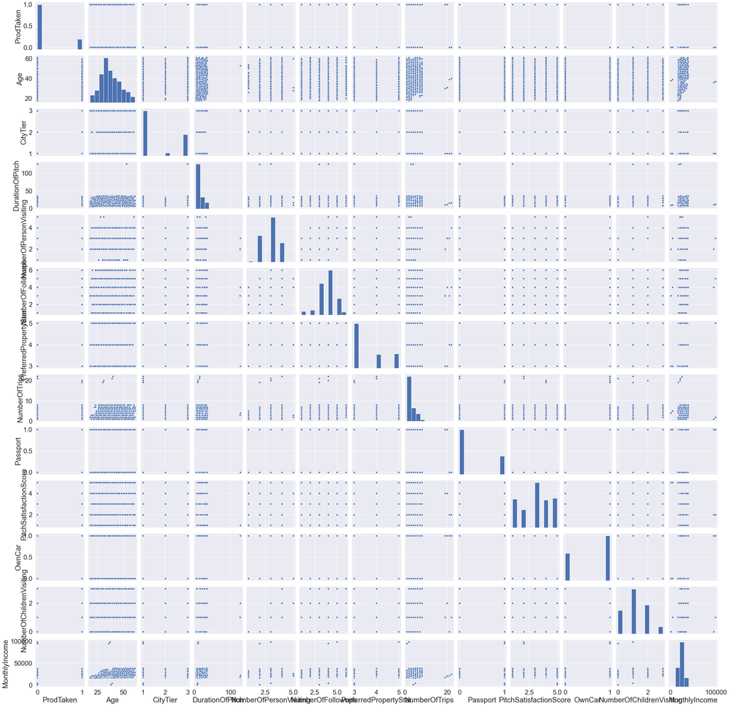

```python
sns.pairplot(df)#To plot the pairplot of all the pairs of the numerical features
plt.show()
```

- We can see varying distributions among the variables which need further invesgation.

```python
# Function to plot stacked bar charts for Personal_Loan against other variables
def stacked_plot(x):
    sns.set()
    ## crosstab
    tab1 = pd.crosstab(x, df["ProdTaken"], margins=True).sort_values(
        by=1, ascending=False
    )
    print(tab1)
    print("-" * 120)
    ## visualising the cross tab
    tab = pd.crosstab(x, df["ProdTaken"], normalize="index").sort_values(
        by=1, ascending=False
    )
    tab.plot(kind="bar", stacked=True, figsize=(17, 7))
    plt.legend(
        loc="lower left",
        frameon=False,
    )
    plt.legend(loc="upper left", bbox_to_anchor=(1, 1))
    plt.show()
```

### ProdTaken Vs Age

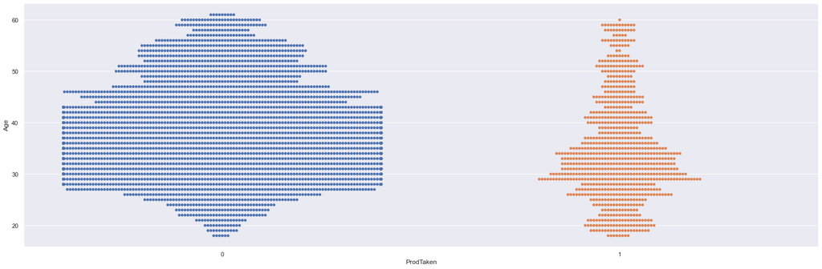

```python
sns.set(rc={'figure.figsize':(21,7)})
sns.catplot(x='ProdTaken',y='Age',data=df,height=7,kind='swarm',aspect=3)
```

```
ProdTaken     0    1   All
Age
All        3786  876  4662
29.0        121   57   178
30.0        151   48   199
34.0        167   44   211
31.0        162   41   203
33.0        149   40   189
32.0        157   40   197
26.0         69   37   106
35.0        203   34   237
27.0        108   30   138
36.0        204   27   231
28.0        121   26   147
20.0         13   25    38
41.0        131   24   155
37.0        161   24   185
40.0        123   23   146
21.0         18   23    41
19.0         11   21    32
25.0         54   20    74
42.0        122   20   142
24.0         38   18    56
45.0         98   18   116
44.0         88   17   105
51.0         73   17    90
38.0        161   15   176
22.0         31   15    46
39.0        136   14   150
52.0         54   14    68
23.0         33   13    46
47.0         76   12    88
56.0         46   12    58
50.0         74   12    86
59.0         32   12    44
58.0         20   11    31
48.0         54   11    65
46.0        110   11   121
43.0        120   10   130
49.0         56    9    65
53.0         58    8    66
18.0          6    8    14
55.0         57    7    64
57.0         24    5    29
54.0         59    2    61
60.0         28    1    29
61.0          9    0     9
------------------------------------------------------------------------------------------------------------------------
```

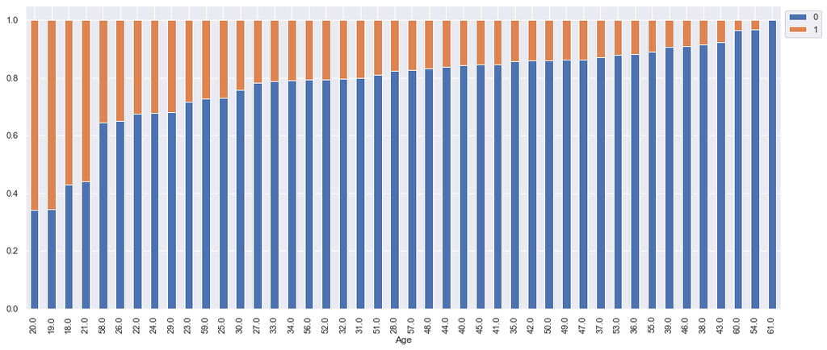

```python
stacked_plot(df.Age)  # to plot stacked barplot of ProdTaken and Age
```

- Customers between ages 18 to 21years all have more than 50% likelihood of purchasing a travel package.
- Top 48% 0f the customers that purchased travel packages last year are within ages 26 to 36 years.

### ProdTaken Vs TypeofContact

```
ProdTaken           0    1   All
TypeofContact
All              3946  917  4863
Self Enquiry     2837  607  3444
Company Invited  1109  310  1419
------------------------------------------------------------------------------------------------------------------------
```

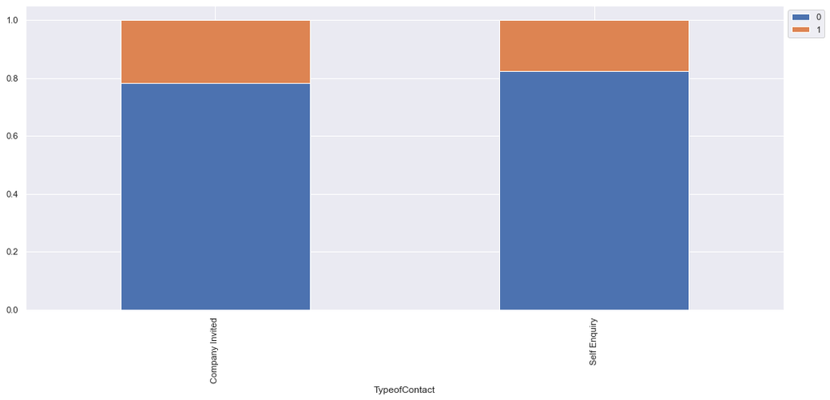

```python
stacked_plot(df.TypeofContact)  # to plot stacked barplot of ProdTaken and TypeofContact
```

- The customers that are company invited have over 20% likehood of purchasing travel packages but those that made self enquiry have less than 20% likelihood of purchasing travel packages. However, customers that made self enquiry purchased travel packages more than those that are company invited.

### ProdTaken Vs CityTier

```
ProdTaken     0    1   All
CityTier
All        3968  920  4888
1          2670  520  3190
3          1146  354  1500
2           152   46   198
------------------------------------------------------------------------------------------------------------------------
```

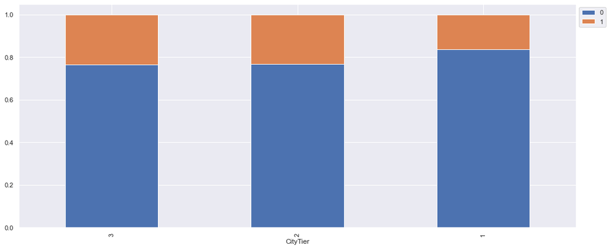

```python
stacked_plot(df.CityTier)  # to plot stacked barplot of ProdTaken and CityTier
```

- Customers from Tier 3 cities have the highest probability of purchasing travel packages among other customers. However,customers from Tier 1 cities bought travel packages most among other tiers.

### ProdTaken Vs Occupation

```
ProdTaken          0    1   All
Occupation
All             3968  920  4888
Salaried        1954  414  2368
Small Business  1700  384  2084
Large Business   314  120   434
Free Lancer        0    2     2
------------------------------------------------------------------------------------------------------------------------
```

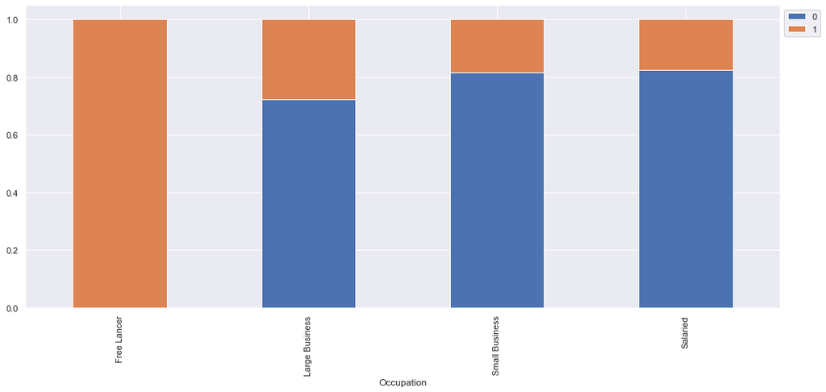

```python
stacked_plot(df.Occupation)  # to plot stacked barplot of ProdTaken and Occupation
```

- The two customers who are Freelancers purchased travel packages. However, Salaried customers purchased the highest number of travel packages as shown in the table above

### ProdTaken Vs Gender

```
ProdTaken     0    1   All
Gender
All        3968  920  4888
Male       2338  578  2916
Female     1630  342  1972
------------------------------------------------------------------------------------------------------------------------
```

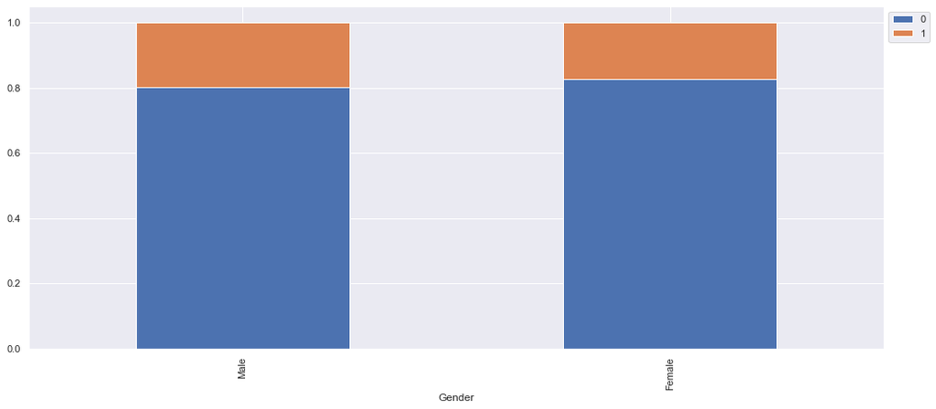

```python
stacked_plot(df.Gender)  # to plot stacked barplot of ProdTaken and Gender
```

- It can observed from both the table and the barplot that Males purchase more of travel packages and also have a higher probability of purchasing travel packages than then females

### ProdTaken Vs NumberOfPersonVisiting

```
ProdTaken                  0    1   All
NumberOfPersonVisiting
All                     3968  920  4888
3                       1942  460  2402
2                       1151  267  1418
4                        833  193  1026
1                         39    0    39
5                          3    0     3
------------------------------------------------------------------------------------------------------------------------
```

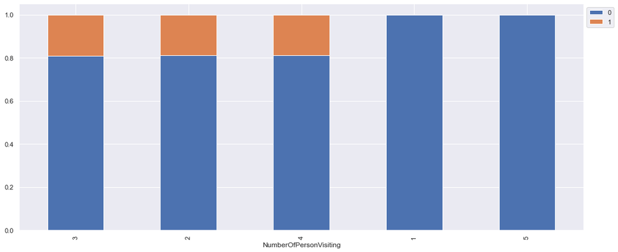

```python
stacked_plot(df.NumberOfPersonVisiting)  # to plot stacked barplot of ProdTaken and NumberOfPersonVisiting
```

- It can be observed that customers with 3 persons planning to take the trip with them have the highest probability of purchasing travel packages and even actually purchased highest number of travel packages last year among other customers. Customers that are planning visit for themselves alone and those with five persons planning to take the trip with them are not likely to purchase any travel package.

### ProdTaken Vs PreferredPropertyStar

```
ProdTaken                 0    1   All
PreferredPropertyStar
All                    3948  914  4862
3.0                    2511  482  2993
5.0                     706  250   956
4.0                     731  182   913
------------------------------------------------------------------------------------------------------------------------
```

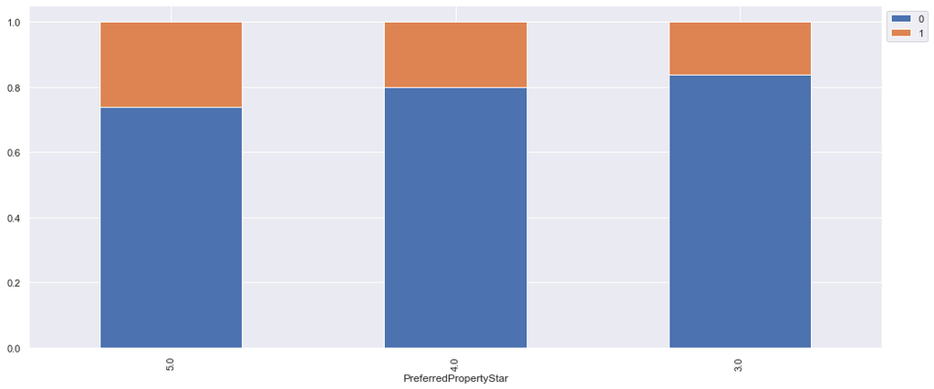

```python
stacked_plot(df.PreferredPropertyStar)  # to plot stacked barplot of ProdTaken and PreferredPropertyStar
```

- Customers with preferred hotel property rating 5 have the highest probability of purchasing travel packages among other customers. However, customers with preferred hotel property rating 3 purchased more than 50% of the total travel packages sold last year

### ProdTaken Vs MaritalStatus

```
ProdTaken         0    1   All
MaritalStatus
All            3968  920  4888
Married        2014  326  2340
Single          612  304   916
Unmarried       516  166   682
Divorced        826  124   950
------------------------------------------------------------------------------------------------------------------------
```

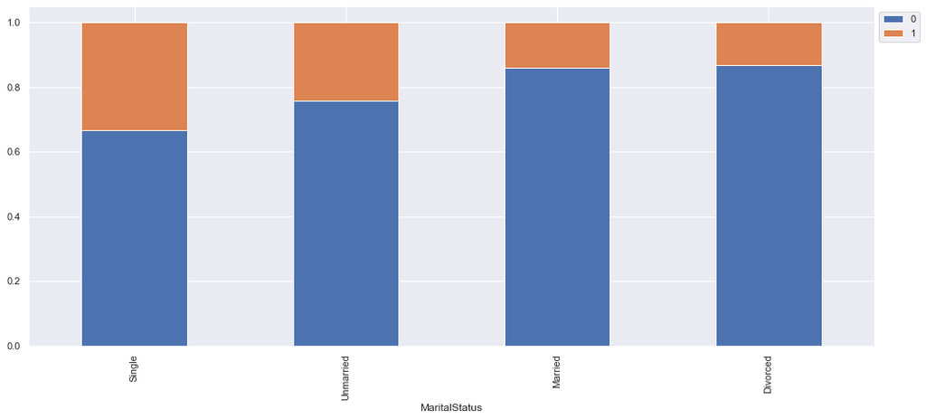

```python
stacked_plot(df.MaritalStatus)  # to plot stacked barplot of ProdTaken and MaritalStatus
```

- Customers who are singles have over 30% probability of purchasing travel packages but Divorcees have the least tendency to purchase travel packages. Married customers however actually purchased the highest number of travel packages last year as shown from the table above